1. the top three factors that contribute to turnover

```r
library(dplyr)
df_hr=read.csv("CaseStudy2_data.csv")
dim(df_hr)
```

```
## [1] 870  36
```

```r
head(df_hr)
```

```
##   ID Age Attrition    BusinessTravel DailyRate             Department
## 1  1  32        No     Travel_Rarely       117                  Sales
## 2  2  40        No     Travel_Rarely      1308 Research & Development
## 3  3  35        No Travel_Frequently       200 Research & Development
## 4  4  32        No     Travel_Rarely       801                  Sales
## 5  5  24        No Travel_Frequently       567 Research & Development
## 6  6  27        No Travel_Frequently       294 Research & Development
##   DistanceFromHome Education   EducationField EmployeeCount EmployeeNumber
## 1               13         4    Life Sciences             1            859
## 2               14         3          Medical             1           1128
## 3               18         2    Life Sciences             1           1412
## 4                1         4        Marketing             1           2016
## 5                2         1 Technical Degree             1           1646
## 6               10         2    Life Sciences             1            733
##   EnvironmentSatisfaction Gender HourlyRate JobInvolvement JobLevel
```

[output cut: 41 more lines]

I guess top 3 is JobRole, MonthlyIncome, OverTime. Let’s check it.

check the plausible factors related to attrition ; monthly income, job role, overtime, travel

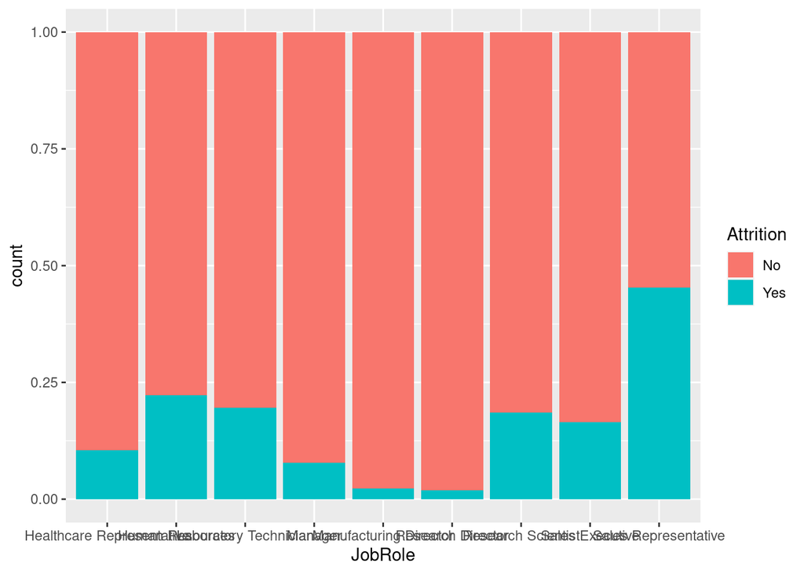

```r
library("ggplot2")
ggplot(df_hr, aes(x=JobRole, fill=Attrition)) + geom_bar(position = "fill")
```

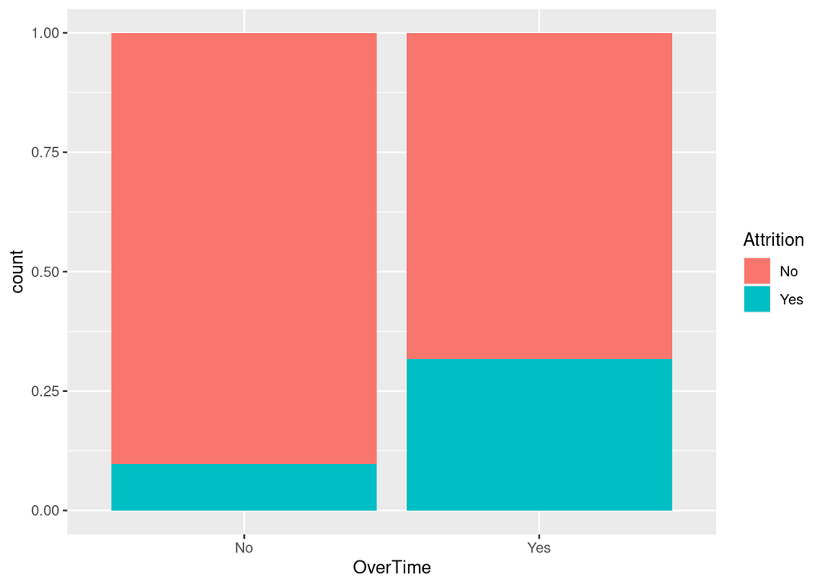

```r
ggplot(df_hr, aes(x=OverTime, fill=Attrition)) + geom_bar(position = "fill")
```

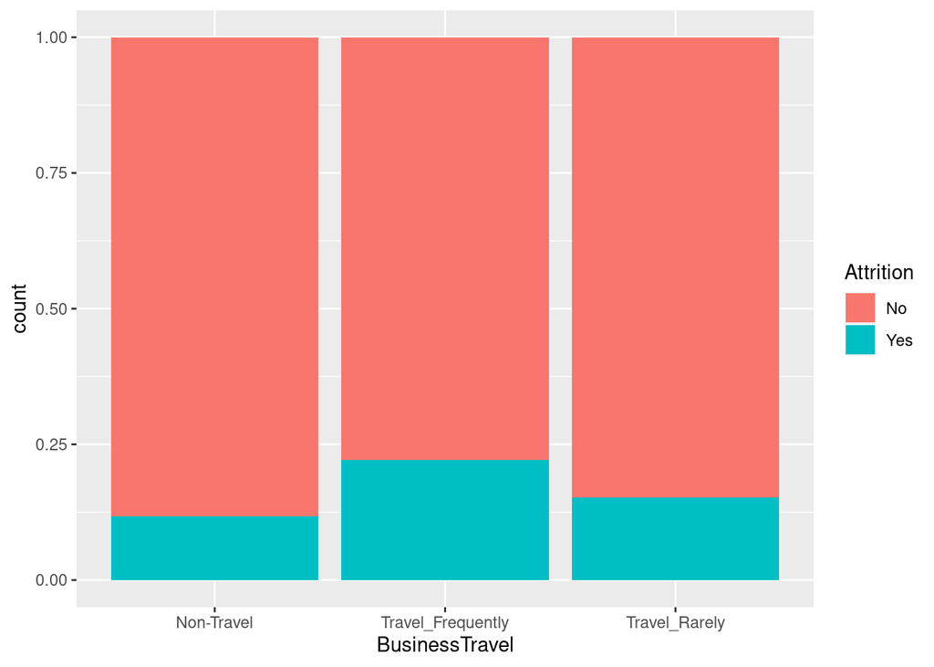

```r
ggplot(df_hr, aes(x=BusinessTravel, fill=Attrition)) + geom_bar(position = "fill")
```

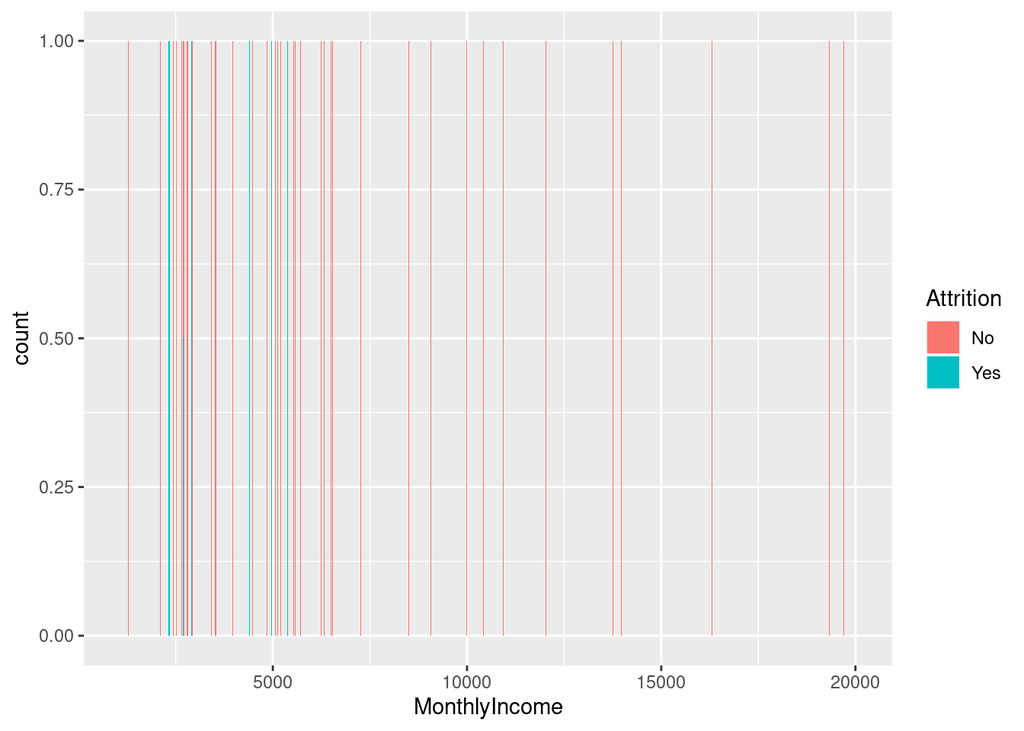

```r
ggplot(df_hr, aes(x=MonthlyIncome, fill=Attrition)) + geom_bar(position = "fill")
```

Jobrole, overtime and business travel gives good idea but monthly income doesn’t cause too many categories. I want to check one thing before re-define income level. BTW, These factors are also related to the Attrition. interesting. (MaritalStatus, JobSatisfaction, JobInvolvement, JobLevel,EnvironmentSatisfaction,Education,Age)

it will be better to re-scale the monthly income and check.

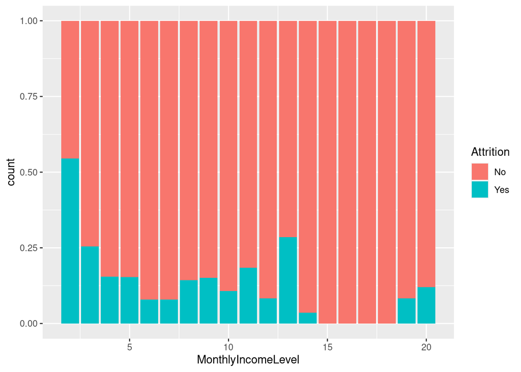

```r
df_MonthlyIncome = 0
for (x in 1:nrow(df_hr)) {
  if(df_hr$MonthlyIncome[x]<1000){df_MonthlyIncome[x] = 1}
  else if(df_hr$MonthlyIncome[x]>=1000 & df_hr$MonthlyIncome[x]<2000){df_MonthlyIncome[x] = 2}
  else if(df_hr$MonthlyIncome[x]>=2000 & df_hr$MonthlyIncome[x]<3000){df_MonthlyIncome[x] = 3}
  else if(df_hr$MonthlyIncome[x]>=3000 & df_hr$MonthlyIncome[x]<4000){df_MonthlyIncome[x] = 4}
  else if(df_hr$MonthlyIncome[x]>=4000 & df_hr$MonthlyIncome[x]<5000){df_MonthlyIncome[x] = 5}
  else if(df_hr$MonthlyIncome[x]>=5000 & df_hr$MonthlyIncome[x]<6000){df_MonthlyIncome[x] = 6}
  else if(df_hr$MonthlyIncome[x]>=6000 & df_hr$MonthlyIncome[x]<7000){df_MonthlyIncome[x] = 7}
  else if(df_hr$MonthlyIncome[x]>=7000 & df_hr$MonthlyIncome[x]<8000){df_MonthlyIncome[x] = 8}
  else if(df_hr$MonthlyIncome[x]>=8000 & df_hr$MonthlyIncome[x]<9000){df_MonthlyIncome[x] = 9}
  else if(df_hr$MonthlyIncome[x]>=9000 & df_hr$MonthlyIncome[x]<10000){df_MonthlyIncome[x] = 10}
  else if(df_hr$MonthlyIncome[x]>=10000 & df_hr$MonthlyIncome[x]<11000){df_MonthlyIncome[x] = 11}
  else if(df_hr$MonthlyIncome[x]>=11000 & df_hr$MonthlyIncome[x]<12000){df_MonthlyIncome[x] = 12}
  else if(df_hr$MonthlyIncome[x]>=12000 & df_hr$MonthlyIncome[x]<13000){df_MonthlyIncome[x] = 13}
  else if(df_hr$MonthlyIncome[x]>=13000 & df_hr$MonthlyIncome[x]<14000){df_MonthlyIncome[x] = 14}
  else if(df_hr$MonthlyIncome[x]>=14000 & df_hr$MonthlyIncome[x]<15000){df_MonthlyIncome[x] = 15}
  else if(df_hr$MonthlyIncome[x]>=15000 & df_hr$MonthlyIncome[x]<16000){df_MonthlyIncome[x] = 16}
  else if(df_hr$MonthlyIncome[x]>=16000 & df_hr$MonthlyIncome[x]<17000){df_MonthlyIncome[x] = 17}
  else if(df_hr$MonthlyIncome[x]>=17000 & df_hr$MonthlyIncome[x]<18000){df_MonthlyIncome[x] = 18}
  else if(df_hr$MonthlyIncome[x]>=18000 & df_hr$MonthlyIncome[x]<19000){df_MonthlyIncome[x] = 19}
  else if(df_hr$MonthlyIncome[x]>=19000 & df_hr$MonthlyIncome[x]<20000){df_MonthlyIncome[x] = 20}
else {df_MonthlyIncome[x] = 8}
}
df_re=df_hr
df_re$MonthlyIncomeLevel <- df_MonthlyIncome
ggplot(df_re, aes(x=MonthlyIncomeLevel, fill=Attrition)) + geom_bar(position = "fill")
```

```r
hello1 <- df_hr %>% group_by(JobRole) %>% summarize(meanIncome = mean(MonthlyIncome), count = n()) %>% arrange(meanIncome)
print(hello1)
```

```
## # A tibble: 9 × 3
##   JobRole                   meanIncome count
##   <chr>                          <dbl> <int>
## 1 Sales Representative           2653.    53
## 2 Laboratory Technician          3222.   153
## 3 Research Scientist             3259.   172
## 4 Human Resources                3285.    27
## 5 Sales Executive                6892.   200
## 6 Healthcare Representative      7435.    76
## 7 Manufacturing Director         7505.    87
## 8 Research Director             15750.    51
## 9 Manager                       17197.    51
```

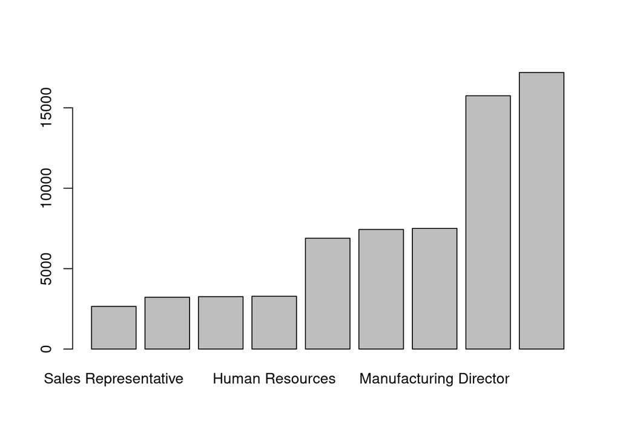

```r
barplot(hello1$meanIncome, names.arg = hello1$JobRole)
```

this gives good idea that the income is highly related with job role. And there are three levels of income here. under 50k, 50k~100k, over 100k.I will recast montlhyincome for only attrition prediction not salary prediction.

re-define categorical variables like BusinessTravel,Department, EducationField, Gender,JobRole,MaritalStatus,OverTime, etc Gender first! cause only two types for now.

Male is 1

```r
library("stringr")
df_Gender <- 1*str_detect(df_hr$Gender, "Male")
df_cv=df_hr
df_cv$Gender<-df_Gender
```

BusinessTravel Travel_rarely:0 Travel_Frequently:1 Non-Travel:2

```r
df_BusinessTravel = ifelse(str_detect(df_hr$BusinessTravel,"Travel_Rarely")==TRUE,"0",ifelse(str_detect(df_hr$BusinessTravel,"Travel_Frequently")==TRUE,"1","2"))
df_cv$BusinessTravel<-df_BusinessTravel
```

attrition No is 1

```r
df_Attrition <- 1*str_detect(df_hr$Attrition, "No")
df_cv$Attrition<-df_Attrition
```

Sales 0 Research & Development 1 Human Resources 2

```r
df_Department = ifelse(str_detect(df_hr$Department,"Sales")==TRUE,"0",ifelse(str_detect(df_hr$Department,"Research & Development")==TRUE,"1","2"))
df_cv$Department<-df_Department
```

Healthcare Representative 1 Human Resources 2 Laboratory Technician 3 Manager 4 Manufacturing Director 5 Research Director 6 Research Scientist 7 Sales Executive 8 Sales Representative 9

```r
df_cv$JobRole<-as.integer(factor(df_hr$JobRole, levels = c("Healthcare Representative", "Human Resources","Laboratory Technician","Manager","Manufacturing Director","Research Director","Research Scientist","Sales Executive","Sales Representative")))
```

```r
df_cv$MaritalStatus<-as.integer(factor(df_hr$MaritalStatus, levels = c("Divorced", "Married","Single")))
```

Over18 Yes 1 No 2

```r
df_cv$Over18<-as.integer(factor(df_hr$Over18, levels = c("Y", "N")))
```

OverTime Yes 1 No 2

```r
df_cv$OverTime<-as.integer(factor(df_hr$OverTime, levels = c("Yes", "No")))
```

EducationField Life Sciences 1 Medical 2 Marketing 3 Technical Degree 4 Human Resources 5 Other 6

```r
df_cv$EducationField<-as.integer(factor(df_hr$EducationField, levels = c("Life Sciences", "Medical","Marketing","Technical Degree","Human Resources","Other")))
```

correlation map for attrition

[figure not shown]

```r
library(GGally)
# Convert data to numeric
corr <- data.frame(lapply(df_cv, as.integer))
corr$Attri <- corr$Attrition
# Plot the graph
plot_attrition=ggcorr(corr,
    method = c("pairwise", "spearman"),
    nbreaks = 6,
    hjust = 0.8,
    label = TRUE,
    label_size = 2,
    label_round = 4,
    color = "grey50")
plot_attrition
```

```r
head(df_cv)
```

```
##   ID Age Attrition BusinessTravel DailyRate Department DistanceFromHome
## 1  1  32         1              0       117          0               13
## 2  2  40         1              0      1308          1               14
## 3  3  35         1              1       200          1               18
## 4  4  32         1              0       801          0                1
## 5  5  24         1              1       567          1                2
## 6  6  27         1              1       294          1               10
##   Education EducationField EmployeeCount EmployeeNumber EnvironmentSatisfaction
## 1         4              1             1            859                       2
## 2         3              2             1           1128                       3
## 3         2              1             1           1412                       3
## 4         4              3             1           2016                       3
## 5         1              4             1           1646                       1
## 6         2              1             1            733                       4
##   Gender HourlyRate JobInvolvement JobLevel JobRole JobSatisfaction
```

[output cut: 41 more lines]

overtime 0.27, #1

monthly income, .1995 #4 marrital status, .198 #5 total working year, .1996 #3 stock option level, .201 #2

2. interesting trends and observations from your analysis

there will be intended highly turnover rate position.

salary always number 1 factor of retrition so it will be the last choice to reduce retrition. hire more people or promotion and productivity increasing are good way to go

joblevel .9 total working year .7 years at company .5

correlation network

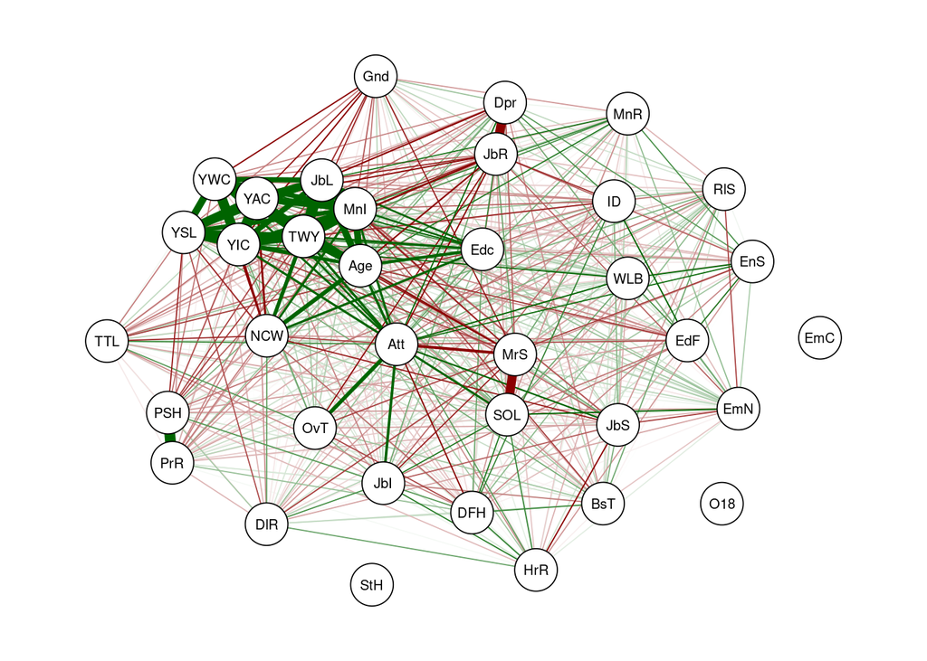

```r
library(qgraph)
#use cor function to create a correlation matrix with milan.mort dataset
#and put into cormat variable
###################################################
corr1 <- data.frame(lapply(df_cv, as.integer))
cormat=cor(corr1)  #correlation matrix generated
###################################################
###################################################
#now plot a graph of the correlation matrix
###################################################
#qgraph(cormat, shape="circle", posCol="darkgreen", negCol="darkred", layout="groups", vsize=10)
qgraph(cormat, shape="circle", posCol="darkgreen", negCol="darkred", layout="spring", vsize=5)
```

lets make rshiny with this

```r
#nodes
cormat=cor(corr1)  #correlation matrix generated
```

```r
diag(cormat) <- 0
cormat[upper.tri(cormat)] <- 0
df_nodes <- list("name"=rownames(cormat),"group"=c(1:36),"size"=c(1:36))
df_nodes <- as.data.frame(df_nodes)

#links
rownames(cormat) <- c(0:35)
colnames(cormat) <- c(0:35)
cormat <- cormat %>% replace(is.na(.), 0)
cormat=abs(cormat*100)
cormat=format(round(cormat))
cormat <- cormat %>% replace(is.na(.), 0)
df_pairs=as.data.frame(as.table(cormat))
df_links=df_pairs
names(df_links) <- c("source","target","Freq")
df_links=df_links[order(df_links$Freq, decreasing = TRUE), ]
df_links = df_links[1:60,]


library(networkD3)

forceNetwork(Links = df_links, Nodes = df_nodes, Source = "source",
             Target = "target", Value = "Freq", NodeID = "name",
             Group = "group", opacity = 0.4, fontSize = 30, zoom = T)
```

[interactive chart not shown]

write.csv(df_nodes, file = “df_nodes.csv”) write.csv(df_links, file = “df_links.csv”)

3. predict attrition

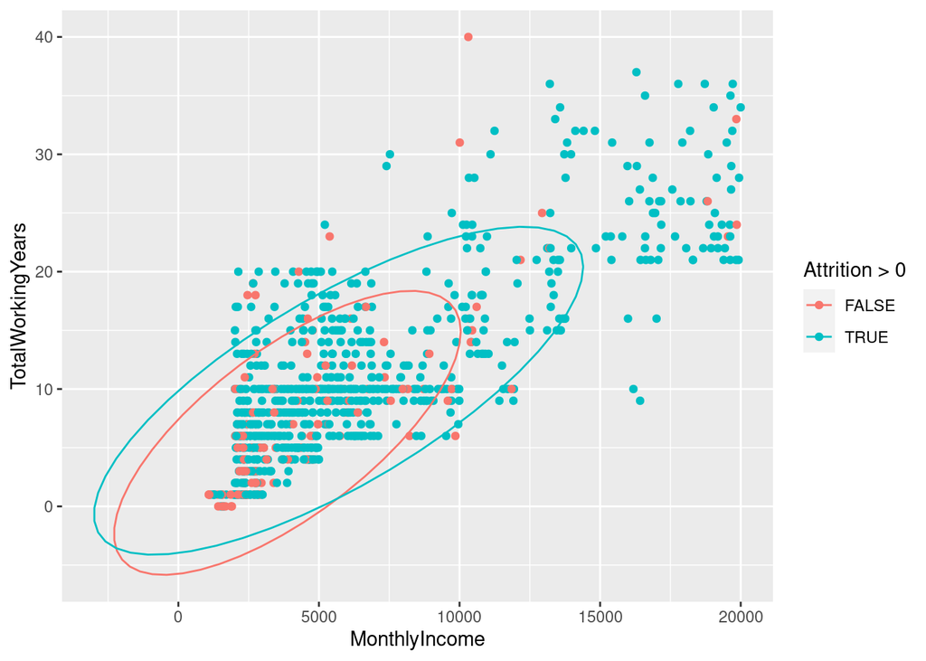

```r
df_cv %>% ggplot(aes(x = MonthlyIncome, y = TotalWorkingYears, color=Attrition > 0)) +
geom_point() +
stat_ellipse()
```

Lots of outliers!

```r
#70/30 training/
# Loop for many k and the average of many training / test partition
hello_scale=df_cv

set.seed(300)
iterations = 1
numks = 1
splitPerc = .70


for(j in 1:iterations)
{
  trainIndices = sample(1:dim(hello_scale)[1],round(splitPerc * dim(hello_scale)[1]))
  train = hello_scale[trainIndices,]
  test = hello_scale[-trainIndices,]
  for(i in 1:numks)
  {formula = Attrition ~ Age + BusinessTravel + Department + Education + JobLevel + JobRole + MonthlyIncome + NumCompaniesWorked  + OverTime  + StockOptionLevel + TotalWorkingYears + YearsAtCompany + StockOptionLevel + YearsWithCurrManager + YearsInCurrentRole
classifications =  glm(formula, data = train, family = binomial())
  }

}
summary(classifications)
```

```
##
## Call:
## glm(formula = formula, family = binomial(), data = train)
##
## Deviance Residuals:
##     Min       1Q   Median       3Q      Max
## -3.0869   0.2064   0.3777   0.5646   1.5235
##
## Coefficients:
##                        Estimate Std. Error z value Pr(>|z|)
## (Intercept)          -3.574e+00  1.152e+00  -3.101  0.00193 **
## Age                   2.333e-02  1.938e-02   1.204  0.22867
## BusinessTravel1      -7.673e-01  2.977e-01  -2.578  0.00995 **
## BusinessTravel2       2.226e-01  4.359e-01   0.511  0.60962
## Department1           1.003e+00  4.199e-01   2.390  0.01687 *
## Department2           2.405e-01  7.702e-01   0.312  0.75482
## Education            -8.390e-03  1.277e-01  -0.066  0.94761
## JobLevel              7.055e-01  4.257e-01   1.657  0.09743 .
## JobRole               6.698e-02  7.716e-02   0.868  0.38534
## MonthlyIncome        -5.872e-05  1.025e-04  -0.573  0.56683
## NumCompaniesWorked   -1.577e-01  5.471e-02  -2.883  0.00394 **
## OverTime              1.479e+00  2.574e-01   5.745  9.2e-09 ***
## StockOptionLevel      3.875e-01  1.577e-01   2.457  0.01401 *
## TotalWorkingYears     6.075e-02  4.652e-02   1.306  0.19163
## YearsAtCompany       -9.437e-02  5.981e-02  -1.578  0.11463
## YearsWithCurrManager  5.678e-02  6.814e-02   0.833  0.40471
## YearsInCurrentRole    6.921e-02  6.359e-02   1.088  0.27641
## ---
## Signif. codes:  0 '***' 0.001 '**' 0.01 '*' 0.05 '.' 0.1 ' ' 1
##
## (Dispersion parameter for binomial family taken to be 1)
##
##     Null deviance: 520.55  on 608  degrees of freedom
## Residual deviance: 423.57  on 592  degrees of freedom
## AIC: 457.57
##
## Number of Fisher Scoring iterations: 6
```

```r
predicted <- predict(classifications, test, type = 'response')
```

accuracy

```r
# confusion matrix
table_mat <- table(test$Attrition, predicted>0.5)
table_mat
```

```
##
##     FALSE TRUE
##   0    10   37
##   1     1  213
```

```r
TP = table_mat[1,1]
FP = table_mat[1,2]
FN = table_mat[2,1]
TN = table_mat[2,2]
accuracy = (TN+TP)/(TN+TP+FP+TP)
accuracy
```

```
## [1] 0.8259259
```

```r
sensitivity = TP/(TP+FN)
sensitivity
```

```
## [1] 0.9090909
```

```r
specificity = TN/(TN+FP)
specificity
```

```
## [1] 0.852
```

confusion matrix in caret threshold default is .5 https://www.rdocumentation.org/packages/InformationValue/versions/1.2.3/topics/confusionMatrix

4. predict salary let’s change model to linear mod

```r
library("caret")
linearMod <- lm(train$MonthlyIncome ~ JobLevel + TotalWorkingYears + YearsAtCompany, data=train)
#
summary(linearMod)
```

```
##
## Call:
## lm(formula = train$MonthlyIncome ~ JobLevel + TotalWorkingYears +
##     YearsAtCompany, data = train)
##
## Residuals:
##     Min      1Q  Median      3Q     Max
## -5653.6  -909.0    55.1   715.6  3863.0
##
## Coefficients:
##                   Estimate Std. Error t value Pr(>|t|)
## (Intercept)       -1724.76     122.15 -14.119  < 2e-16 ***
## JobLevel           3687.49      83.84  43.982  < 2e-16 ***
## TotalWorkingYears    75.44      13.39   5.634 2.71e-08 ***
## YearsAtCompany      -38.18      12.61  -3.028  0.00256 **
## ---
## Signif. codes:  0 '***' 0.001 '**' 0.01 '*' 0.05 '.' 0.1 ' ' 1
##
## Residual standard error: 1390 on 605 degrees of freedom
## Multiple R-squared:  0.904,  Adjusted R-squared:  0.9036
## F-statistic:  1900 on 3 and 605 DF,  p-value: < 2.2e-16
```

```r
# now use it to predict the salary


predict = predict(linearMod, test, inverval="predict")


RMSE(test$MonthlyIncome,predict)
```

```
## [1] 1368.084
```